# **Wine Quality Exploration by Ricardo Yoshitomi**

# Introduction

The purpose of this project is to perform an Exploratory Data Analysis (EDA) in a chosen dataset with R. I have chosen to work with the Red Wine Quality dataset. For this project, I consulted the materials on the instruction notes and accessed the http://www.statmethods.net/ and https://stackoverflow.com/ pages. This analysis is based on a research conducted by Cortez *et al*. (2009) in which 11 chemical properties of 1599 red wine samples were measured and the quality of each sample evaluated by wine experts. Each expert graded the wine quality between 0 (very bad) and 10 (very excellent). Data mining methods were applied to determine which chemical properties have the most influence on the quality of red wines. For more information about this work consult:

P. Cortez, A. Cerdeira, F. Almeida, T. Matos and J. Reis. Modeling wine preferences by data mining from physicochemical properties. In Decision Support Systems, Elsevier, 47(4):547-553. ISSN: 0167-9236.

Available at:

- [@Elsevier] http://dx.doi.org/10.1016/j.dss.2009.05.016
- [Pre-press (pdf)] http://www3.dsi.uminho.pt/pcortez/winequality09.pdf
- [bib] http://www3.dsi.uminho.pt/pcortez/dss09.bi

# Univariate Plots Section

```
## [1] 1599   13
```

```
## 'data.frame':    1599 obs. of  13 variables:
##  $ X                   : int  1 2 3 4 5 6 7 8 9 10 ...
##  $ fixed.acidity       : num  7.4 7.8 7.8 11.2 7.4 7.4 7.9 7.3 7.8 7.5 ...
##  $ volatile.acidity    : num  0.7 0.88 0.76 0.28 0.7 0.66 0.6 0.65 0.58 0.5 ...
##  $ citric.acid         : num  0 0 0.04 0.56 0 0 0.06 0 0.02 0.36 ...
##  $ residual.sugar      : num  1.9 2.6 2.3 1.9 1.9 1.8 1.6 1.2 2 6.1 ...
##  $ chlorides           : num  0.076 0.098 0.092 0.075 0.076 0.075 0.069 0.065 0.073 0.071 ...
##  $ free.sulfur.dioxide : num  11 25 15 17 11 13 15 15 9 17 ...
##  $ total.sulfur.dioxide: num  34 67 54 60 34 40 59 21 18 102 ...
##  $ density             : num  0.998 0.997 0.997 0.998 0.998 ...
##  $ pH                  : num  3.51 3.2 3.26 3.16 3.51 3.51 3.3 3.39 3.36 3.35 ...
##  $ sulphates           : num  0.56 0.68 0.65 0.58 0.56 0.56 0.46 0.47 0.57 0.8 ...
##  $ alcohol             : num  9.4 9.8 9.8 9.8 9.4 9.4 9.4 10 9.5 10.5 ...
##  $ quality             : int  5 5 5 6 5 5 5 7 7 5 ...
```

```
##        X          fixed.acidity   volatile.acidity  citric.acid
##  Min.   :   1.0   Min.   : 4.60   Min.   :0.1200   Min.   :0.000
##  1st Qu.: 400.5   1st Qu.: 7.10   1st Qu.:0.3900   1st Qu.:0.090
##  Median : 800.0   Median : 7.90   Median :0.5200   Median :0.260
##  Mean   : 800.0   Mean   : 8.32   Mean   :0.5278   Mean   :0.271
##  3rd Qu.:1199.5   3rd Qu.: 9.20   3rd Qu.:0.6400   3rd Qu.:0.420
##  Max.   :1599.0   Max.   :15.90   Max.   :1.5800   Max.   :1.000
##  residual.sugar     chlorides       free.sulfur.dioxide
##  Min.   : 0.900   Min.   :0.01200   Min.   : 1.00
##  1st Qu.: 1.900   1st Qu.:0.07000   1st Qu.: 7.00
##  Median : 2.200   Median :0.07900   Median :14.00
##  Mean   : 2.539   Mean   :0.08747   Mean   :15.87
##  3rd Qu.: 2.600   3rd Qu.:0.09000   3rd Qu.:21.00
##  Max.   :15.500   Max.   :0.61100   Max.   :72.00
##  total.sulfur.dioxide    density             pH          sulphates
##  Min.   :  6.00       Min.   :0.9901   Min.   :2.740   Min.   :0.3300
##  1st Qu.: 22.00       1st Qu.:0.9956   1st Qu.:3.210   1st Qu.:0.5500
##  Median : 38.00       Median :0.9968   Median :3.310   Median :0.6200
##  Mean   : 46.47       Mean   :0.9967   Mean   :3.311   Mean   :0.6581
##  3rd Qu.: 62.00       3rd Qu.:0.9978   3rd Qu.:3.400   3rd Qu.:0.7300
##  Max.   :289.00       Max.   :1.0037   Max.   :4.010   Max.   :2.0000
##     alcohol         quality
##  Min.   : 8.40   Min.   :3.000
##  1st Qu.: 9.50   1st Qu.:5.000
##  Median :10.20   Median :6.000
##  Mean   :10.42   Mean   :5.636
##  3rd Qu.:11.10   3rd Qu.:6.000
##  Max.   :14.90   Max.   :8.000
```

The dataset contains thirteen variables, with 1599 observations.

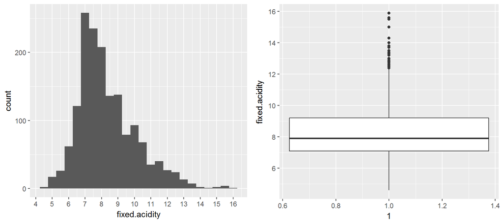

```
##    Min. 1st Qu.  Median    Mean 3rd Qu.    Max.
##    4.60    7.10    7.90    8.32    9.20   15.90
```

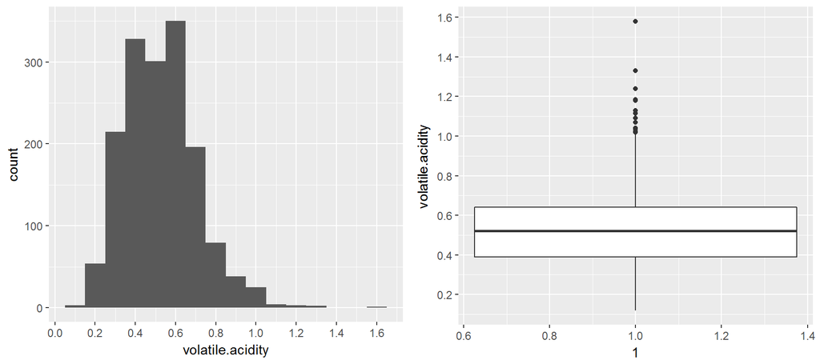

```
##    Min. 1st Qu.  Median    Mean 3rd Qu.    Max.
##  0.1200  0.3900  0.5200  0.5278  0.6400  1.5800
```

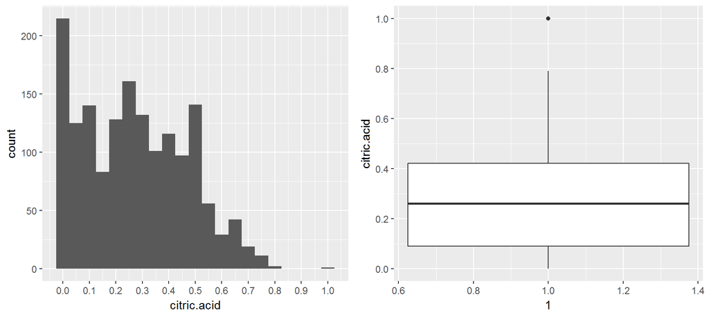

```
##    Min. 1st Qu.  Median    Mean 3rd Qu.    Max.
##   0.000   0.090   0.260   0.271   0.420   1.000
```

The fixed acidity (tartaric acid) distribution is slightly right-skewed, with most wine samples between 6 g/dm<sup>3</sup> and 10 g/dm<sup>3</sup>, the maximum peak appears around 7 g/dm<sup>3</sup>. The boxplot indicates the outliers are above 12 g/dm<sup>3</sup> with the maximum value 15.9 g/dm<sup>3</sup>.

Most of the wine instances have the volatile acidity (acetic acid) between 0.3 g/dm<sup>3</sup> and 0.7 g/dm<sup>3</sup>. The median and mean are 0.52 g/dm<sup>3</sup> and 0.5278 g/dm<sup>3</sup>, respectively. The outliers appear above the value 1 g/dm<sup>3</sup>.

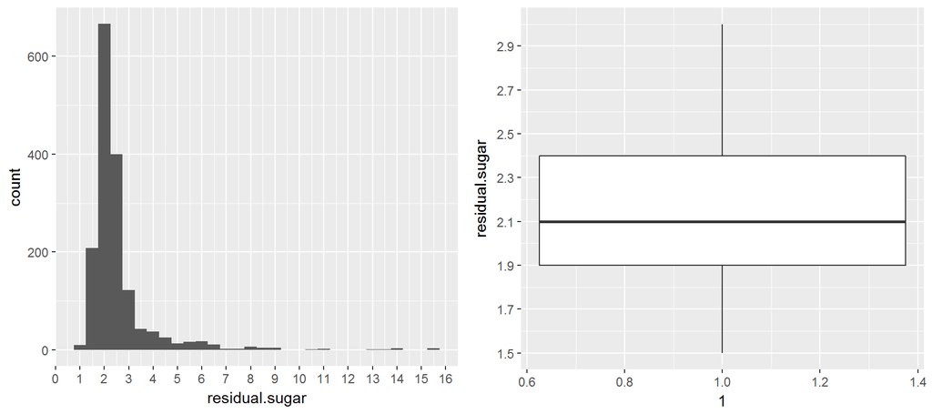

```
##    Min. 1st Qu.  Median    Mean 3rd Qu.    Max.
##   0.900   1.900   2.200   2.539   2.600  15.500
```

```
##
## (1.5,1.75]   (1.75,2]   (2,2.25] (2.25,2.5] (2.5,2.75]   (2.75,3]
##        138        402        264        280        120        100
```

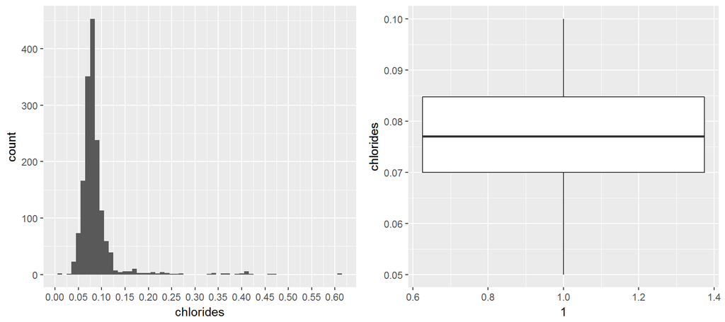

```
##    Min. 1st Qu.  Median    Mean 3rd Qu.    Max.
## 0.01200 0.07000 0.07900 0.08747 0.09000 0.61100
```

```
##
## (0.05,0.06] (0.06,0.07] (0.07,0.08] (0.08,0.09]  (0.09,0.1]
##         103         245         464         329         173
```

For the residual sugar quantities, most of the wine samples have between 1.9 g/dm<sup>3</sup> and 2.6 g/dm<sup>3</sup>. There is a peak in evidence around 2 g/dm<sup>3</sup>. It is difficult to find wines with less than 1 g/dm<sup>3</sup> and greater than 7 g/dm<sup>3</sup>, wines with greater than 45 g/dm<sup>3</sup> are considered sweet. The boxplot is limited to only see the bulk of the residual sugar. It is noticed that the median slightly changed for 2.1 g/dm<sup>3</sup>.

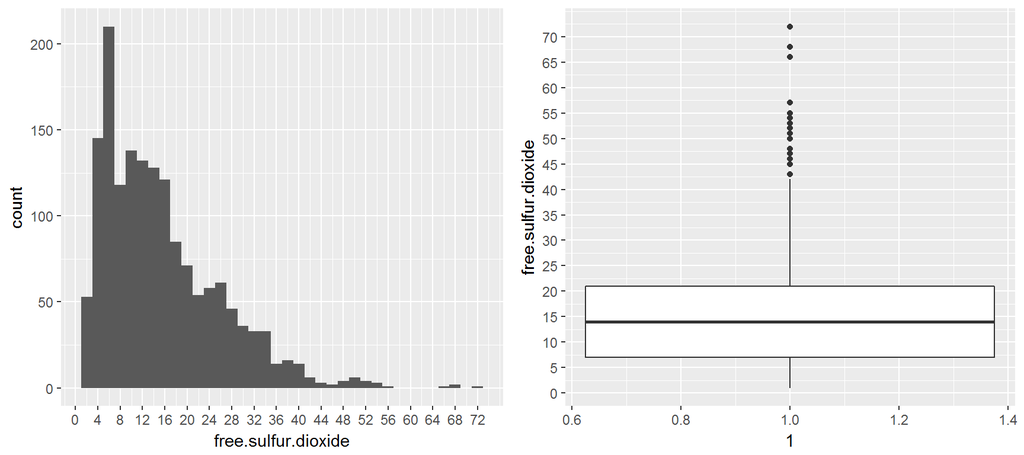

```
##    Min. 1st Qu.  Median    Mean 3rd Qu.    Max.
##    1.00    7.00   14.00   15.87   21.00   72.00
```

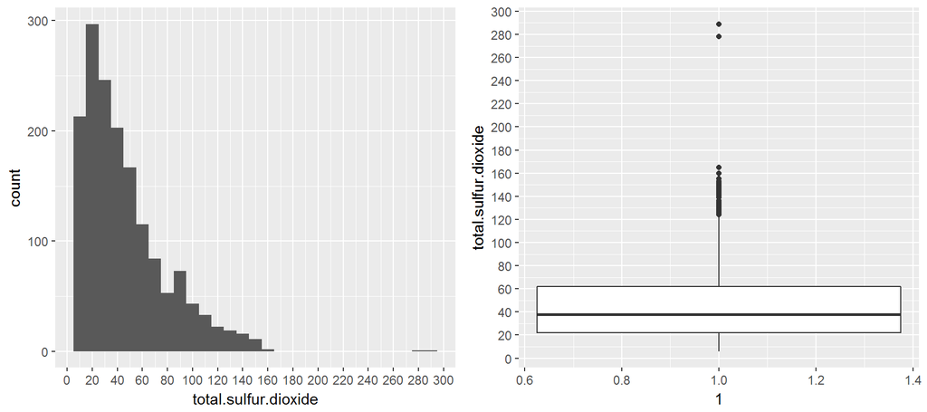

```
##    Min. 1st Qu.  Median    Mean 3rd Qu.    Max.
##    6.00   22.00   38.00   46.47   62.00  289.00
```

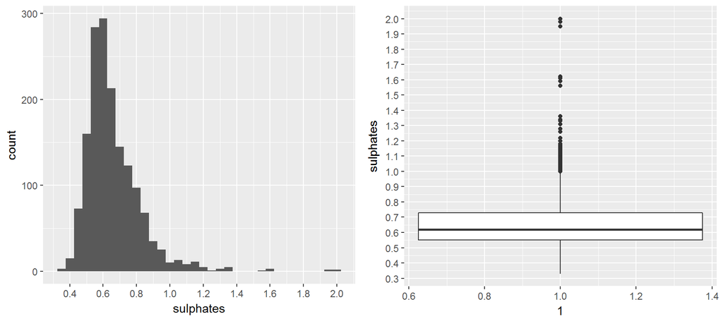

```
##    Min. 1st Qu.  Median    Mean 3rd Qu.    Max.
##  0.3300  0.5500  0.6200  0.6581  0.7300  2.0000
```

The three previous plots represent the distribution of the sulfur dioxide (SO2) in the wine. The SO2 has both antimicrobial and antioxidant functions, and with high levels, it may influence the smell and taste of the wine. All the three plots are right skewed.

The first plot is the distribution of the free sulfur dioxide which is the free form of SO2 in equilibrium with molecular SO2 (as a dissolved gas) and bisulfite ion. This component appears in low concentrations ranging from 1 mg/dm<sup>3</sup> (minimum) to 72 mg/dm<sup>3</sup> (maximum). Most of wine samples have the free sulfur dioxide between 4 mg/dm<sup>3</sup> and 25 mg/dm<sup>3</sup>. The outliers are above 40 mg/dm<sup>3</sup>.

The second plot represents the distribution of the total sulfur dioxide which is the amount of free and bound forms of S02. The bulk part of the distribution ranges from 6 mg/dm<sup>3</sup> to 160 mg/dm<sup>3</sup>. The outliers appear in two regions, one is close to the bulk part around the value 150 mg/dm<sup>3</sup> and the other is distant around 289 mg/dm<sup>3</sup> (maximum).

The third plot is the sulphates (potassium sulphate) distribution, the sulphate is a wine additive used to control the sulfur dioxide gas (S02) levels. The most part of the distribution ranges from 0.5 g/dm<sup>3</sup> to 1 g/dm<sup>3</sup>. The outliers appear above 1 g/dm<sup>3</sup>.

Later, I’d like to know the influence of sulphates on the production of sulfur dioxide (SO2) in the wine and how these variables are correlated.

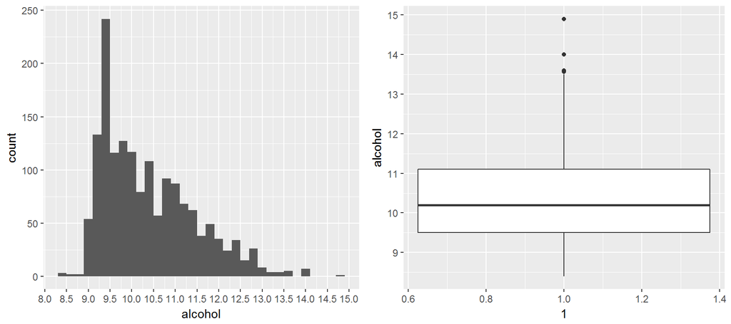

```
##    Min. 1st Qu.  Median    Mean 3rd Qu.    Max.
##    8.40    9.50   10.20   10.42   11.10   14.90
```

```
##
##   (9,9.5]  (9.5,10] (10,10.5] (10.5,11] (11,11.5] (11.5,12] (12,12.5]
##       399       311       236       208       158       109        71
## (12.5,13] (13,13.5]
##        47        10
```

The percent alcohol content distribution is right skewed and it decreases gradually as the percent content increases. Most of wine samples have the percent alcohol content between 9 vol% and 13 vol%: median 10.2 vol% and 10.42 vol%. There are few outliers above 13.5 vol%.

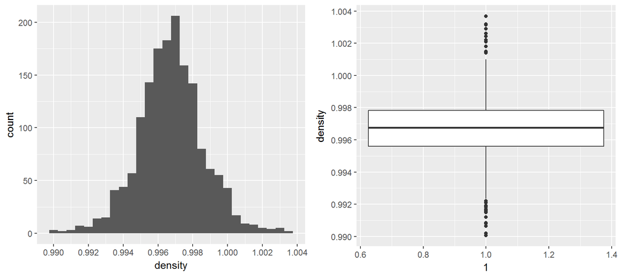

```
##    Min. 1st Qu.  Median    Mean 3rd Qu.    Max.
##  0.9901  0.9956  0.9968  0.9967  0.9978  1.0040
```

The density of wine plot approximates to a normal distribution, the mean and median are very close to each other with values of 0.9967 g/cm<sup>3</sup> and 0.9968 g/cm<sup>3</sup>, respectively. In this case, the outliers appear on the both side of the distribution. The density depends on the percent alcohol and sugar content, later we will study this relationship and how it influences the density to be close to the water.

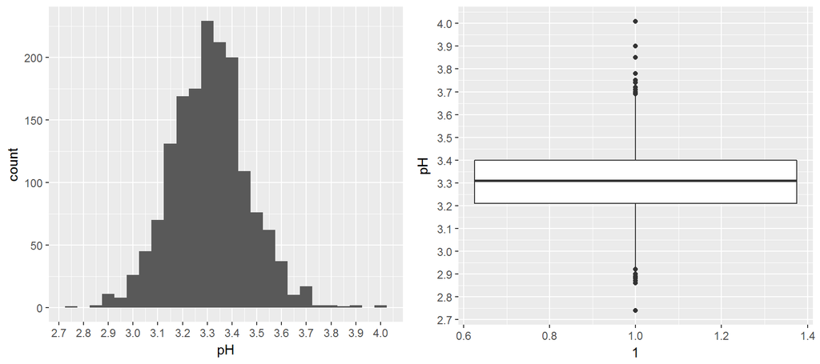

```
##    Min. 1st Qu.  Median    Mean 3rd Qu.    Max.
##   2.740   3.210   3.310   3.311   3.400   4.010
```

The pH is a numeric scale used to specify the acidity or basicity of a solution. Solutions with pH less than 7 are considered acid and solutions with pH greater than 7 are basic. Pure water is neutral with pH 7. Most wines samples are between 3.0 and 3.7 as we can see on the plot. So the wine is considered acid. It is worth to study how the acidity concentrations can affect the pH and what is the effect of others components on the pH. Does the alcohol have the effect to neutralize the wine?

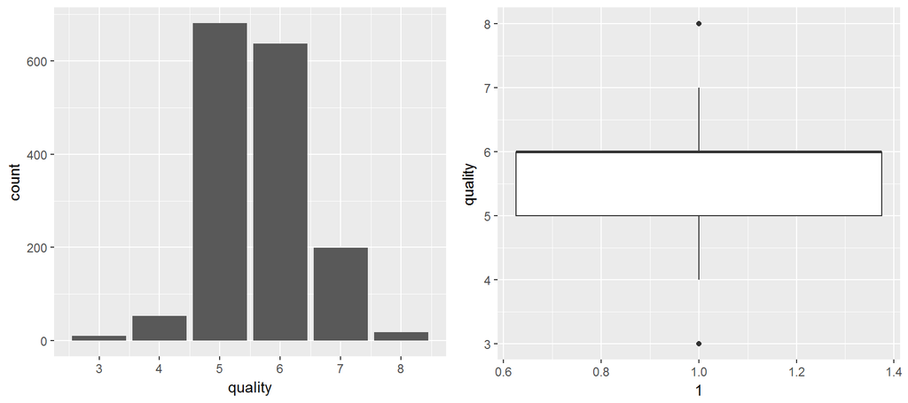

```
##    Min. 1st Qu.  Median    Mean 3rd Qu.    Max.
##   3.000   5.000   6.000   5.636   6.000   8.000
```

In a score from 0 to 10, the median and mean of the quality of the wine are 6 and 5.636, respectively. It is difficult to find scores less than 5 and greater than 7 indicating that most of wines has medium or good qualities. The study is focused on the influence of physicochemical variables on the quality of wines.

# Univariate Analysis

### What is the structure of your dataset?

The dataset contains 1599 red wine samples with 11 variables based on physicochemical tests (fixed acidity, volatile acidity, citric acid, residual sugar, chlorides, free sulfur dioxide, total sulfur dioxide, density, pH, sulphates, alcohol) and 1 sensory variable based on evaluation of wine experts. All measured variables are classified as continuous or quantitatives.

### What is/are the main feature(s) of interest in your dataset?

The main feature in the dataset is quality, it is the unique output variable of the dataset. I’d like to determine which input (physicochemical) variables have relevant importance to improve the wine quality. It is also important to search for outliers in order to detect the few excellent or poor wines.

### What other features in the dataset do you think will help support your investigation into your feature(s) of interest?

All the physicochemical variables can influence the quality of the wine. Other variables such as sulphates contributes to sulfur dioxide levels. The fixed acidity, total sulfur dioxide, density and pH depend on others variables.

### Did you create any new variables from existing variables in the dataset?

No, I didn’t create any new variable.

### Of the features you investigated, were there any unusual distributions? Did you perform any operations on the data to tidy, adjust, or change the form of the data? If so, why did you do this?

No, I didn’t perform any operations to adjust the data.

# Bivariate Plots Section

```
##                           X fixed.acidity volatile.acidity citric.acid
## X                     1.000        -0.268           -0.009      -0.154
## fixed.acidity        -0.268         1.000           -0.256       0.672
## volatile.acidity     -0.009        -0.256            1.000      -0.552
## citric.acid          -0.154         0.672           -0.552       1.000
## residual.sugar       -0.031         0.115            0.002       0.144
## chlorides            -0.120         0.094            0.061       0.204
## free.sulfur.dioxide   0.090        -0.154           -0.011      -0.061
## total.sulfur.dioxide -0.118        -0.113            0.076       0.036
## density              -0.368         0.668            0.022       0.365
## pH                    0.136        -0.683            0.235      -0.542
## sulphates            -0.125         0.183           -0.261       0.313
## alcohol               0.245        -0.062           -0.202       0.110
## quality               0.066         0.124           -0.391       0.226
##                      residual.sugar chlorides free.sulfur.dioxide
## X                            -0.031    -0.120               0.090
## fixed.acidity                 0.115     0.094              -0.154
## volatile.acidity              0.002     0.061              -0.011
## citric.acid                   0.144     0.204              -0.061
## residual.sugar                1.000     0.056               0.187
## chlorides                     0.056     1.000               0.006
## free.sulfur.dioxide           0.187     0.006               1.000
## total.sulfur.dioxide          0.203     0.047               0.668
## density                       0.355     0.201              -0.022
## pH                           -0.086    -0.265               0.070
## sulphates                     0.006     0.371               0.052
## alcohol                       0.042    -0.221              -0.069
## quality                       0.014    -0.129              -0.051
##                      total.sulfur.dioxide density     pH sulphates alcohol
## X                                  -0.118  -0.368  0.136    -0.125   0.245
## fixed.acidity                      -0.113   0.668 -0.683     0.183  -0.062
## volatile.acidity                    0.076   0.022  0.235    -0.261  -0.202
## citric.acid                         0.036   0.365 -0.542     0.313   0.110
## residual.sugar                      0.203   0.355 -0.086     0.006   0.042
## chlorides                           0.047   0.201 -0.265     0.371  -0.221
## free.sulfur.dioxide                 0.668  -0.022  0.070     0.052  -0.069
## total.sulfur.dioxide                1.000   0.071 -0.066     0.043  -0.206
## density                             0.071   1.000 -0.342     0.149  -0.496
## pH                                 -0.066  -0.342  1.000    -0.197   0.206
## sulphates                           0.043   0.149 -0.197     1.000   0.094
## alcohol                            -0.206  -0.496  0.206     0.094   1.000
## quality                            -0.185  -0.175 -0.058     0.251   0.476
##                      quality
## X                      0.066
## fixed.acidity          0.124
## volatile.acidity      -0.391
## citric.acid            0.226
## residual.sugar         0.014
## chlorides             -0.129
## free.sulfur.dioxide   -0.051
## total.sulfur.dioxide  -0.185
## density               -0.175
## pH                    -0.058
## sulphates              0.251
## alcohol                0.476
## quality                1.000
```

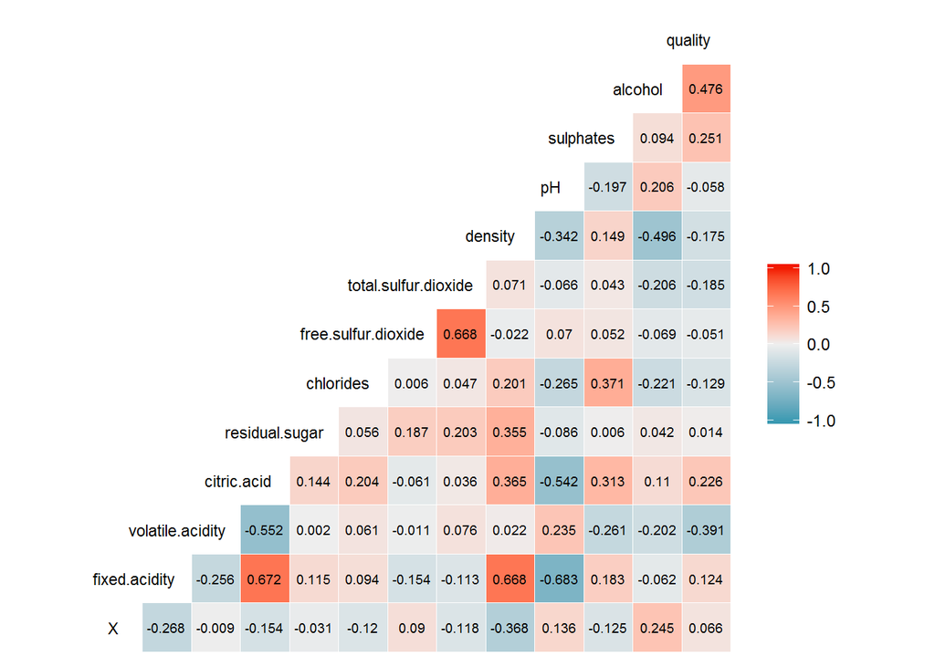

The strongest positive correlations between the physicochemical variables are:

- The fixed acidity is positively correlated with citric acid, the Pearson correlation coefficient is 0.672. According to the author, the fixed acidity is the most acids involved with wine (fixed or nonvolatile) which makes sense.
- The total sulfur dioxide correlates positively with free sulfur dioxide, the correlation coefficient is 0.668. It corresponds to the author’s statement, the total sulfur dioxide is the amount of free and bound forms of S02.
- The fixed acidity correlates positively with density, the correlation coefficient is 0.668. I didn’t expect to find a strong correlation between these variables. But acids can increase the wine’s density since the density of citric acid is about 1,66 g/cm<sup>3</sup> which is greater than the wine.

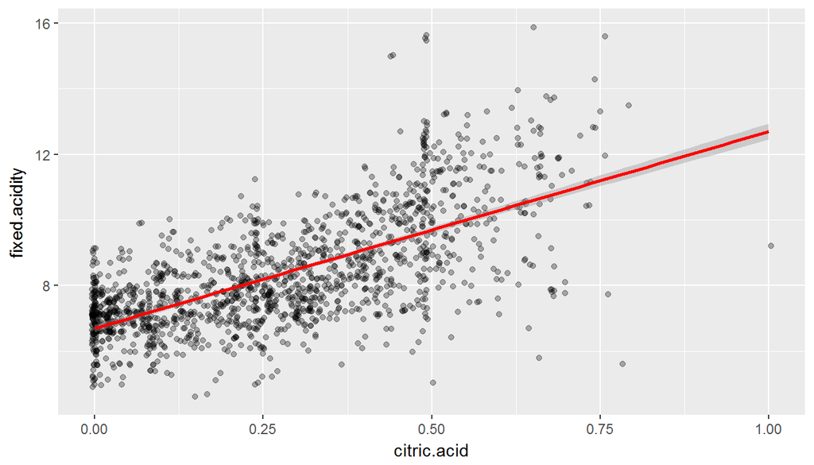

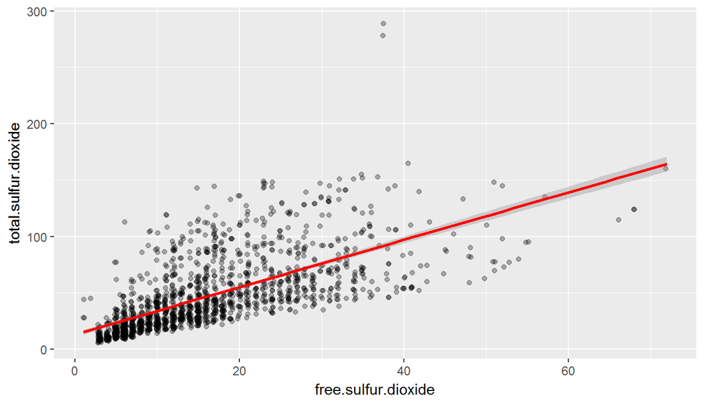

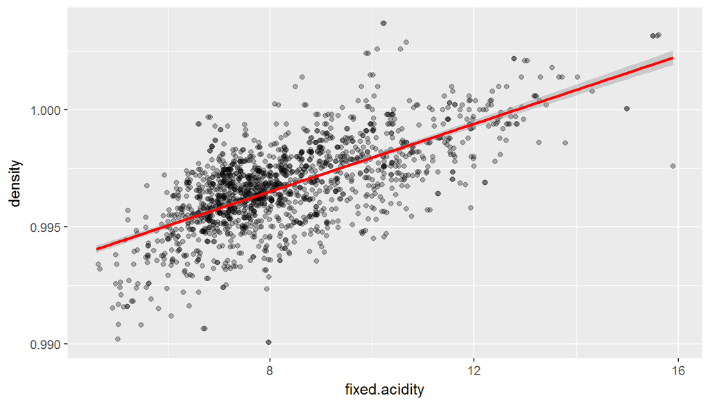

The strongest negative correlations between the physicochemical variables are:

- The citric acid is negatively correlated with pH, the Pearson correlation coefficient is -0.542. It is expected to have a negative correlation between citric acid and pH since high concentrations of acid in a solution decrease the pH index.
- The fixed acidity correlates negatively with pH, the correlation coefficient is -0.683. This coefficient is higher than the coefficient between the citric acid and pH, because the fixed acidity contains the most acids that influence the wine’s pH.
- I expected a negative correlation between the pH and volatile acidity, but it didn’t happen. The correlation coefficient is 0.235 which is low and positive.
- The volatile acidity correlates negatively with citric acid, the correlation coefficient is -0.552. This correlation is very interesting since there is a tendency of yeast to convert citric into acetic acid (Source: https://en.wikipedia.org/wiki/Acids_in_wine#Citric_acid).

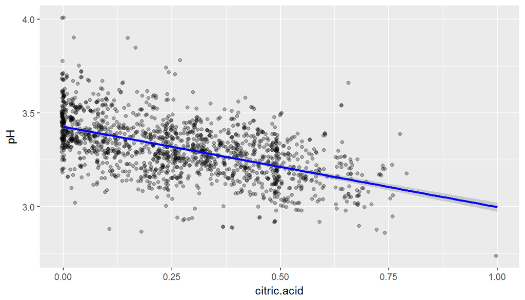

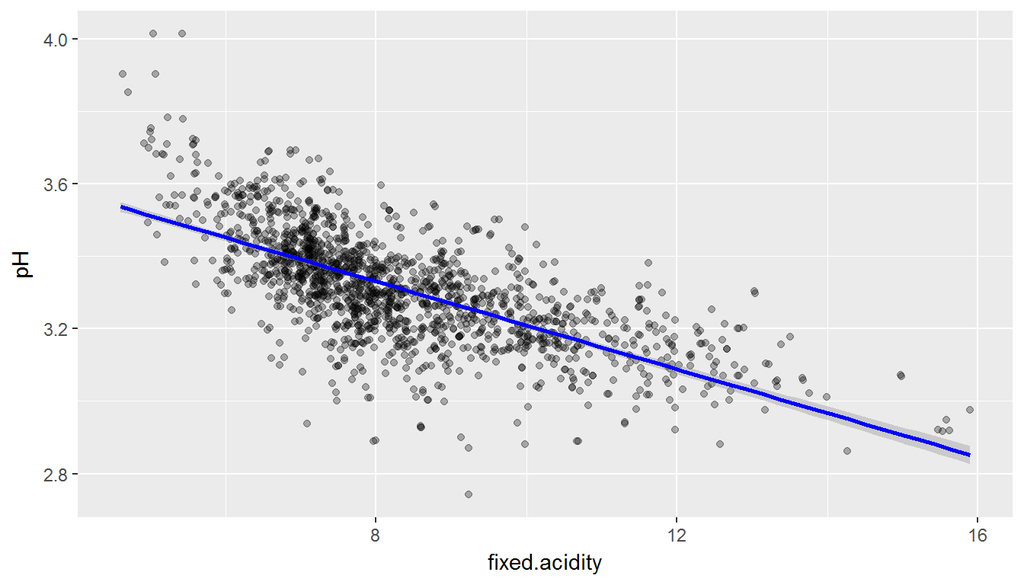

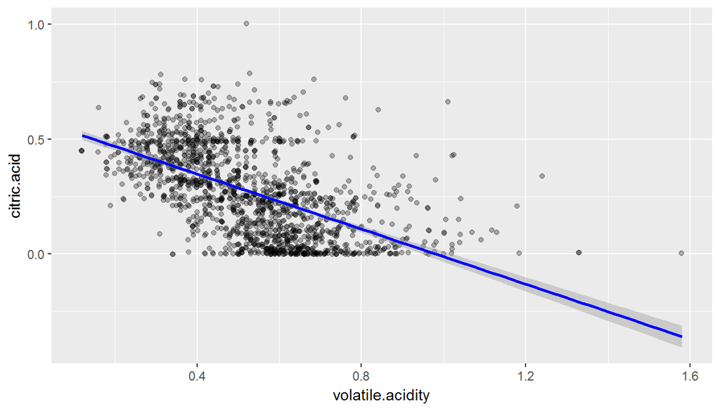

Other observations:

The density is proportional to the initial sugar content (sugar from the grapes) and will be expected to fall as the sugar is converted into alcohol by fermentation (Source: https://en.wikipedia.org/wiki/Red_wine).

- The correlation coefficient between the residual sugar and density is 0.355. This correlation is not strong but is sufficient to influence on the wine’s density since the residual sugar depends on the presence of initial sugar before the fermentation.
- The correlation between the alcohol and density is negative and the coefficient is -0.496. The alcohol’s density is lower than the wine, it is about 0.789 g/cm<sup>3</sup>. It means that in high concentrations the alcohol decreases the density of the wine.
- I didn’t expect to find the fixed acidity would be more correlated with density (the coefficient is 0.668) than residual sugar and alcohol. Most of the fixed acids are present in wine grapes. Fixed acidity is important to determine the density since the beggining of production.
- In addition, the density also slightly correlates with citric acid and pH. Citric acid is part of fixed acidity which is correlated with density and pH depends on the fixed acidity.
- I expected to find a correlation between the sulphates and total sulfur dioxide, as the sulphates is an additive that contributes to sulfur dioxide gas (S02) levels, but there is no significant correlation between these variables.
- Quality is moderately correlated with alcohol, sulphates, citric acid and volatile acidity. Later we will see how each of these variables affect the wine’s quality.

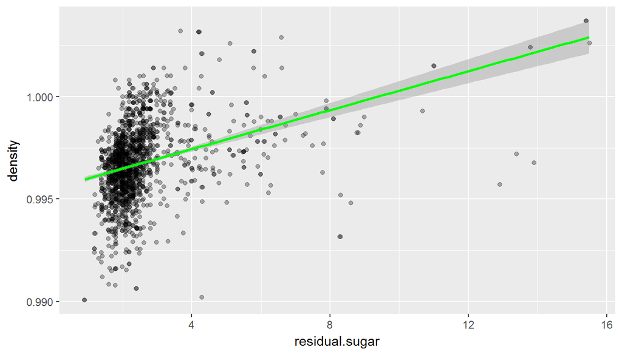

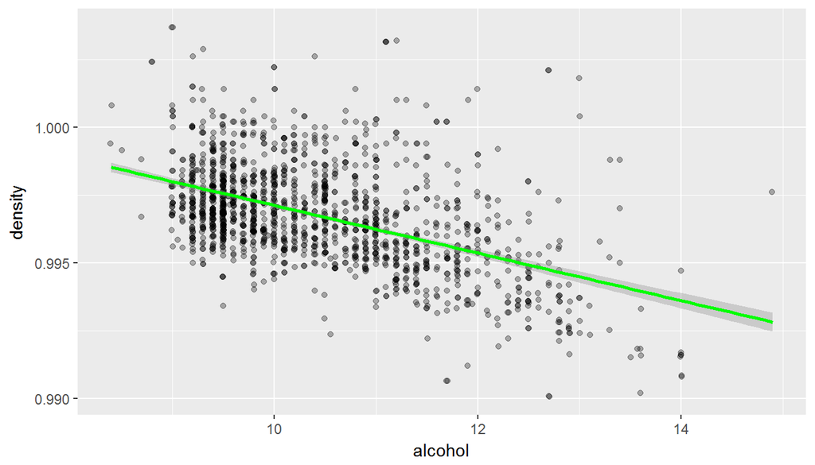

We saw on the correlation matrix that quality doesn’t have a strong correlation with any physicochemical variable. A better approach to understanding the relationships between the physicochemical variables with quality is to use a jitter plot and boxplot.

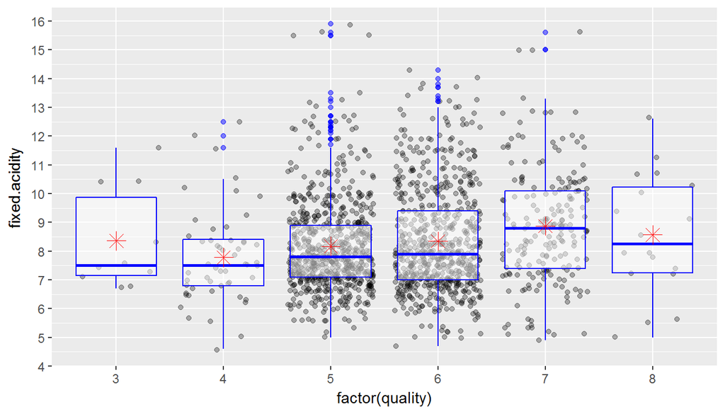

```
## red_wine$quality: 3
##    Min. 1st Qu.  Median    Mean 3rd Qu.    Max.
##   6.700   7.150   7.500   8.360   9.875  11.600
## --------------------------------------------------------
## red_wine$quality: 4
##    Min. 1st Qu.  Median    Mean 3rd Qu.    Max.
##   4.600   6.800   7.500   7.779   8.400  12.500
## --------------------------------------------------------
## red_wine$quality: 5
##    Min. 1st Qu.  Median    Mean 3rd Qu.    Max.
##   5.000   7.100   7.800   8.167   8.900  15.900
## --------------------------------------------------------
## red_wine$quality: 6
##    Min. 1st Qu.  Median    Mean 3rd Qu.    Max.
##   4.700   7.000   7.900   8.347   9.400  14.300
## --------------------------------------------------------
## red_wine$quality: 7
##    Min. 1st Qu.  Median    Mean 3rd Qu.    Max.
##   4.900   7.400   8.800   8.872  10.100  15.600
## --------------------------------------------------------
## red_wine$quality: 8
##    Min. 1st Qu.  Median    Mean 3rd Qu.    Max.
##   5.000   7.250   8.250   8.567  10.230  12.600
```

For the fixed acidity, the plot shows the difference between the qualities are not large. The median of fixed acidity for each quality varies from 7.5 g/dm<sup>3</sup> (minimum) to 8.8 g/dm<sup>3</sup> (maximum) and it is higher for the qualities 7 and 8 and lower for the qualities 3 and 4. It means that wines with higher quantities of fixed acid are better.

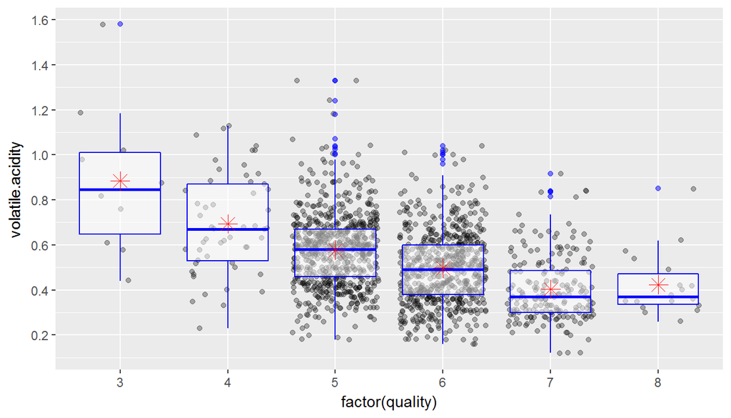

```
## red_wine$quality: 3
##    Min. 1st Qu.  Median    Mean 3rd Qu.    Max.
##  0.4400  0.6475  0.8450  0.8845  1.0100  1.5800
## --------------------------------------------------------
## red_wine$quality: 4
##    Min. 1st Qu.  Median    Mean 3rd Qu.    Max.
##   0.230   0.530   0.670   0.694   0.870   1.130
## --------------------------------------------------------
## red_wine$quality: 5
##    Min. 1st Qu.  Median    Mean 3rd Qu.    Max.
##   0.180   0.460   0.580   0.577   0.670   1.330
## --------------------------------------------------------
## red_wine$quality: 6
##    Min. 1st Qu.  Median    Mean 3rd Qu.    Max.
##  0.1600  0.3800  0.4900  0.4975  0.6000  1.0400
## --------------------------------------------------------
## red_wine$quality: 7
##    Min. 1st Qu.  Median    Mean 3rd Qu.    Max.
##  0.1200  0.3000  0.3700  0.4039  0.4850  0.9150
## --------------------------------------------------------
## red_wine$quality: 8
##    Min. 1st Qu.  Median    Mean 3rd Qu.    Max.
##  0.2600  0.3350  0.3700  0.4233  0.4725  0.8500
```

The previous plot reveals something very interesting on the relationship between volatile acidity and quality. As the median of volatile acidity for each quality gradually decreases, the wine’s quality improves. It makes sense since it is desirable to have small quantities of volatile acidity, too high of levels can lead to an unpleasant, vinegar taste.

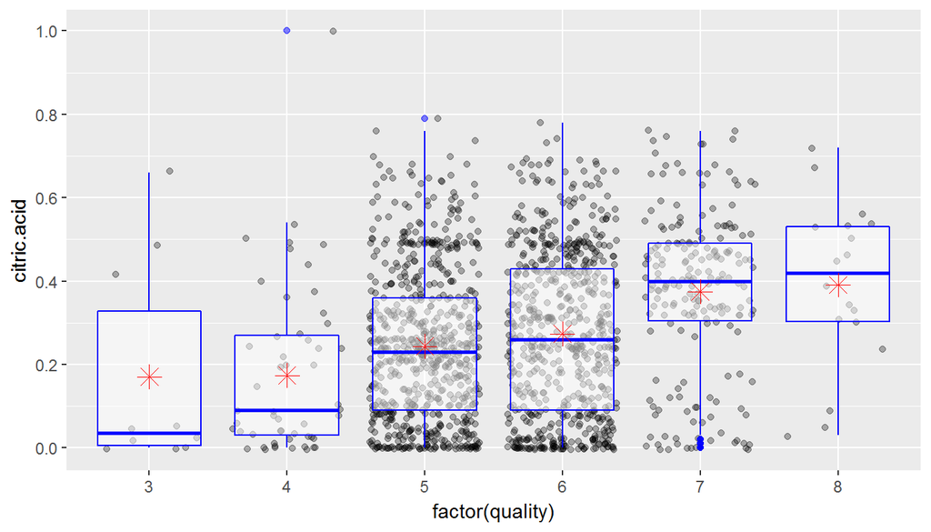

```
## red_wine$quality: 3
##    Min. 1st Qu.  Median    Mean 3rd Qu.    Max.
##  0.0000  0.0050  0.0350  0.1710  0.3275  0.6600
## --------------------------------------------------------
## red_wine$quality: 4
##    Min. 1st Qu.  Median    Mean 3rd Qu.    Max.
##  0.0000  0.0300  0.0900  0.1742  0.2700  1.0000
## --------------------------------------------------------
## red_wine$quality: 5
##    Min. 1st Qu.  Median    Mean 3rd Qu.    Max.
##  0.0000  0.0900  0.2300  0.2437  0.3600  0.7900
## --------------------------------------------------------
## red_wine$quality: 6
##    Min. 1st Qu.  Median    Mean 3rd Qu.    Max.
##  0.0000  0.0900  0.2600  0.2738  0.4300  0.7800
## --------------------------------------------------------
## red_wine$quality: 7
##    Min. 1st Qu.  Median    Mean 3rd Qu.    Max.
##  0.0000  0.3050  0.4000  0.3752  0.4900  0.7600
## --------------------------------------------------------
## red_wine$quality: 8
##    Min. 1st Qu.  Median    Mean 3rd Qu.    Max.
##  0.0300  0.3025  0.4200  0.3911  0.5300  0.7200
```

There is another interesting relationship, now between the citric acid and quality. As the median of citric acid for each quality gradually increases, the quality increases. It means that excellent wines have high levels of citric acid. It makes sense since citric acid can add ‘freshness’ and flavor to wines.

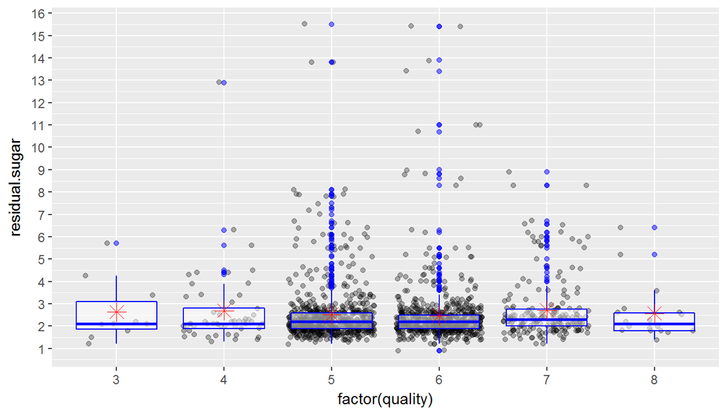

```
## red_wine$quality: 3
##    Min. 1st Qu.  Median    Mean 3rd Qu.    Max.
##   1.200   1.875   2.100   2.635   3.100   5.700
## --------------------------------------------------------
## red_wine$quality: 4
##    Min. 1st Qu.  Median    Mean 3rd Qu.    Max.
##   1.300   1.900   2.100   2.694   2.800  12.900
## --------------------------------------------------------
## red_wine$quality: 5
##    Min. 1st Qu.  Median    Mean 3rd Qu.    Max.
##   1.200   1.900   2.200   2.529   2.600  15.500
## --------------------------------------------------------
## red_wine$quality: 6
##    Min. 1st Qu.  Median    Mean 3rd Qu.    Max.
##   0.900   1.900   2.200   2.477   2.500  15.400
## --------------------------------------------------------
## red_wine$quality: 7
##    Min. 1st Qu.  Median    Mean 3rd Qu.    Max.
##   1.200   2.000   2.300   2.721   2.750   8.900
## --------------------------------------------------------
## red_wine$quality: 8
##    Min. 1st Qu.  Median    Mean 3rd Qu.    Max.
##   1.400   1.800   2.100   2.578   2.600   6.400
```

For the residual sugar, the median and mean of each quality are very close to each other. The values of the median are near 2.2 g/dm<sup>3</sup>. Residual sugar quantity doesn’t change when improving the quality. There are some outliers above 13 g/dm<sup>3</sup> and they are classified as qualities 4, 5 and 6. It means that sweet wines are not considered excellent.

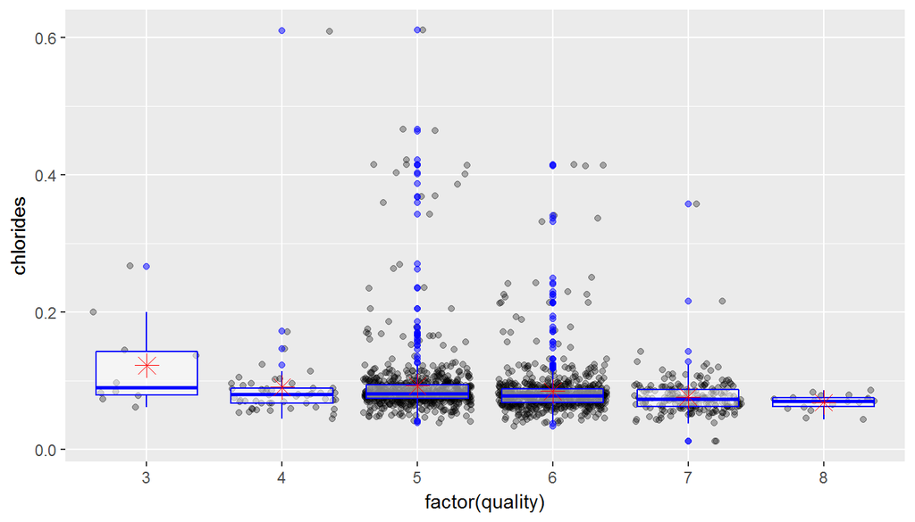

```
## red_wine$quality: 3
##    Min. 1st Qu.  Median    Mean 3rd Qu.    Max.
##  0.0610  0.0790  0.0905  0.1225  0.1430  0.2670
## --------------------------------------------------------
## red_wine$quality: 4
##    Min. 1st Qu.  Median    Mean 3rd Qu.    Max.
## 0.04500 0.06700 0.08000 0.09068 0.08900 0.61000
## --------------------------------------------------------
## red_wine$quality: 5
##    Min. 1st Qu.  Median    Mean 3rd Qu.    Max.
## 0.03900 0.07400 0.08100 0.09274 0.09400 0.61100
## --------------------------------------------------------
## red_wine$quality: 6
##    Min. 1st Qu.  Median    Mean 3rd Qu.    Max.
## 0.03400 0.06825 0.07800 0.08496 0.08800 0.41500
## --------------------------------------------------------
## red_wine$quality: 7
##    Min. 1st Qu.  Median    Mean 3rd Qu.    Max.
## 0.01200 0.06200 0.07300 0.07659 0.08700 0.35800
## --------------------------------------------------------
## red_wine$quality: 8
##    Min. 1st Qu.  Median    Mean 3rd Qu.    Max.
## 0.04400 0.06200 0.07050 0.06844 0.07550 0.08600
```

Chlorides are found in low concentrations in the wine samples, around 0.08 g/dm<sup>3</sup>. The boxplots indicate that the differences between the qualities are not very large, it is noticed the median of chlorides for each quality slightly decreases when improving the quality.

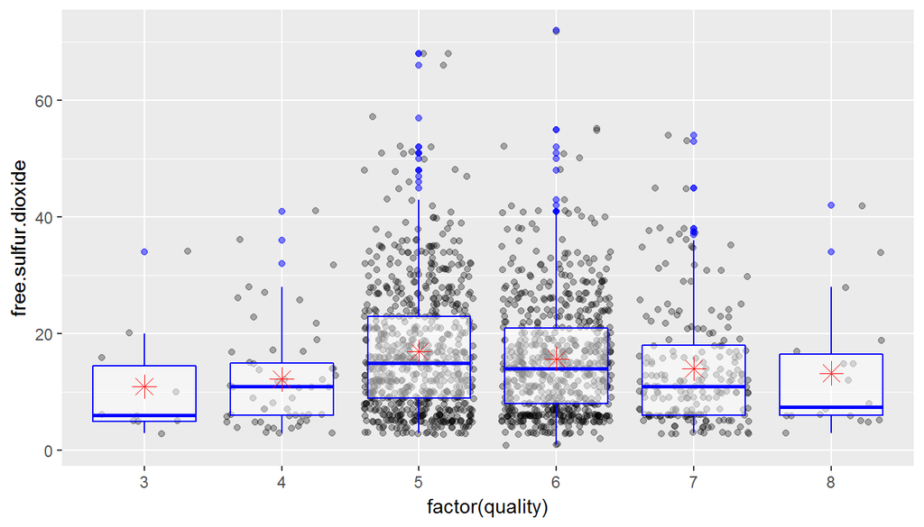

```
## red_wine$quality: 3
##    Min. 1st Qu.  Median    Mean 3rd Qu.    Max.
##     3.0     5.0     6.0    11.0    14.5    34.0
## --------------------------------------------------------
## red_wine$quality: 4
##    Min. 1st Qu.  Median    Mean 3rd Qu.    Max.
##    3.00    6.00   11.00   12.26   15.00   41.00
## --------------------------------------------------------
## red_wine$quality: 5
##    Min. 1st Qu.  Median    Mean 3rd Qu.    Max.
##    3.00    9.00   15.00   16.98   23.00   68.00
## --------------------------------------------------------
## red_wine$quality: 6
##    Min. 1st Qu.  Median    Mean 3rd Qu.    Max.
##    1.00    8.00   14.00   15.71   21.00   72.00
## --------------------------------------------------------
## red_wine$quality: 7
##    Min. 1st Qu.  Median    Mean 3rd Qu.    Max.
##    3.00    6.00   11.00   14.05   18.00   54.00
## --------------------------------------------------------
## red_wine$quality: 8
##    Min. 1st Qu.  Median    Mean 3rd Qu.    Max.
##    3.00    6.00    7.50   13.28   16.50   42.00
```

We can see the plot of the free sulfur dioxide versus quality is almost simetric. The amount of free sulfur dioxide are higher for the qualities 5 and 6 (center) and lower for the qualities 3 and 8 (extremes). It means that higher or lower quantities of free sulfur dioxide don’t improve or worsen the wine’s quality.

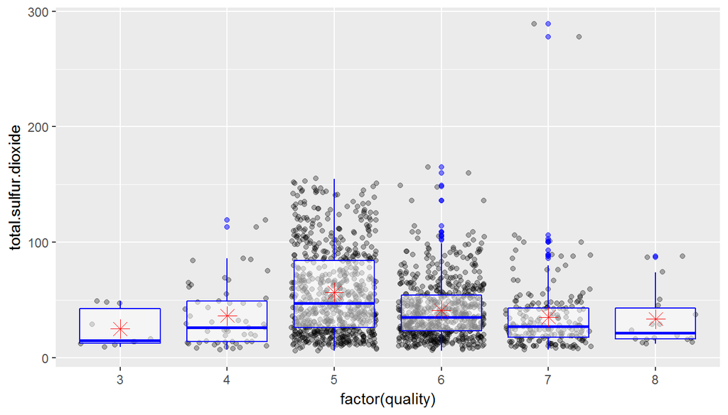

```
## red_wine$quality: 3
##    Min. 1st Qu.  Median    Mean 3rd Qu.    Max.
##     9.0    12.5    15.0    24.9    42.5    49.0
## --------------------------------------------------------
## red_wine$quality: 4
##    Min. 1st Qu.  Median    Mean 3rd Qu.    Max.
##    7.00   14.00   26.00   36.25   49.00  119.00
## --------------------------------------------------------
## red_wine$quality: 5
##    Min. 1st Qu.  Median    Mean 3rd Qu.    Max.
##    6.00   26.00   47.00   56.51   84.00  155.00
## --------------------------------------------------------
## red_wine$quality: 6
##    Min. 1st Qu.  Median    Mean 3rd Qu.    Max.
##    6.00   23.00   35.00   40.87   54.00  165.00
## --------------------------------------------------------
## red_wine$quality: 7
##    Min. 1st Qu.  Median    Mean 3rd Qu.    Max.
##    7.00   17.50   27.00   35.02   43.00  289.00
## --------------------------------------------------------
## red_wine$quality: 8
##    Min. 1st Qu.  Median    Mean 3rd Qu.    Max.
##   12.00   16.00   21.50   33.44   43.00   88.00
```

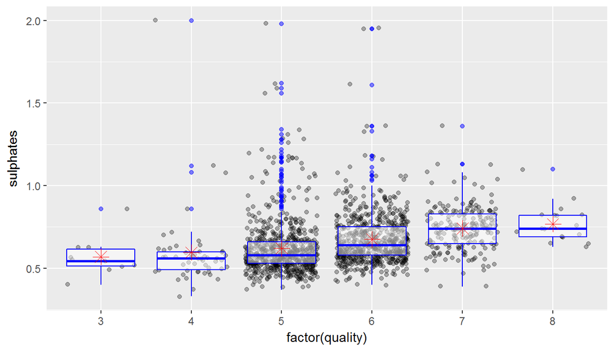

```
## red_wine$quality: 3
##    Min. 1st Qu.  Median    Mean 3rd Qu.    Max.
##  0.4000  0.5125  0.5450  0.5700  0.6150  0.8600
## --------------------------------------------------------
## red_wine$quality: 4
##    Min. 1st Qu.  Median    Mean 3rd Qu.    Max.
##  0.3300  0.4900  0.5600  0.5964  0.6000  2.0000
## --------------------------------------------------------
## red_wine$quality: 5
##    Min. 1st Qu.  Median    Mean 3rd Qu.    Max.
##   0.370   0.530   0.580   0.621   0.660   1.980
## --------------------------------------------------------
## red_wine$quality: 6
##    Min. 1st Qu.  Median    Mean 3rd Qu.    Max.
##  0.4000  0.5800  0.6400  0.6753  0.7500  1.9500
## --------------------------------------------------------
## red_wine$quality: 7
##    Min. 1st Qu.  Median    Mean 3rd Qu.    Max.
##  0.3900  0.6500  0.7400  0.7413  0.8300  1.3600
## --------------------------------------------------------
## red_wine$quality: 8
##    Min. 1st Qu.  Median    Mean 3rd Qu.    Max.
##  0.6300  0.6900  0.7400  0.7678  0.8200  1.1000
```

The plot of sulphates versus quality shows something very interesting. As the median of sulphates for each quality increases, the wine’s quality improves. In the next section we will see the importance of sulphates on the conservation of wine grapes and how it leads to a better wine’s quality.

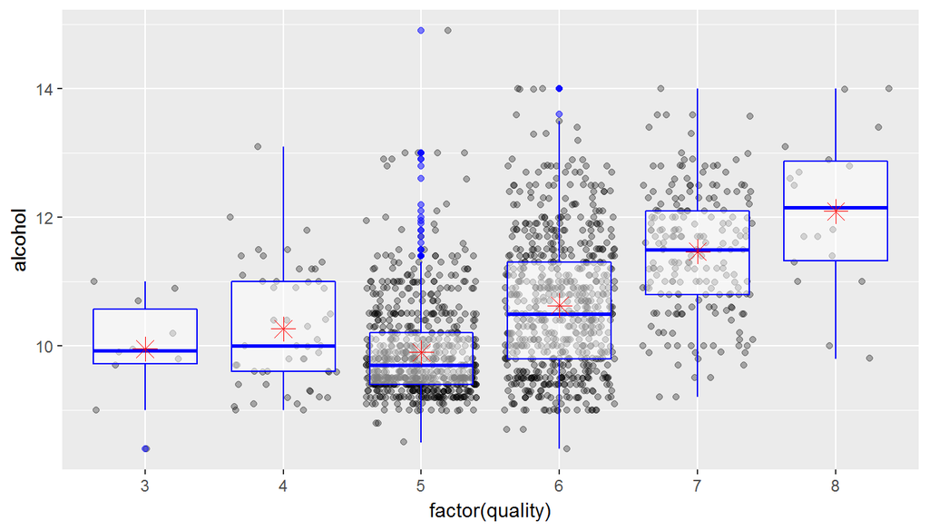

```
## red_wine$quality: 3
##    Min. 1st Qu.  Median    Mean 3rd Qu.    Max.
##   8.400   9.725   9.925   9.955  10.580  11.000
## --------------------------------------------------------
## red_wine$quality: 4
##    Min. 1st Qu.  Median    Mean 3rd Qu.    Max.
##    9.00    9.60   10.00   10.27   11.00   13.10
## --------------------------------------------------------
## red_wine$quality: 5
##    Min. 1st Qu.  Median    Mean 3rd Qu.    Max.
##     8.5     9.4     9.7     9.9    10.2    14.9
## --------------------------------------------------------
## red_wine$quality: 6
##    Min. 1st Qu.  Median    Mean 3rd Qu.    Max.
##    8.40    9.80   10.50   10.63   11.30   14.00
## --------------------------------------------------------
## red_wine$quality: 7
##    Min. 1st Qu.  Median    Mean 3rd Qu.    Max.
##    9.20   10.80   11.50   11.47   12.10   14.00
## --------------------------------------------------------
## red_wine$quality: 8
##    Min. 1st Qu.  Median    Mean 3rd Qu.    Max.
##    9.80   11.32   12.15   12.09   12.88   14.00
```

We can split the previous plot into two sections. In the first section, from the quality 3 to 5, we don’t see any significant change when the quality improves. But in the second section, from the quality 6 to 8, as the median of alcohol for each quality increases, the quality improves. The effect of the alcohol to improve the wine’s quality takes place after the quality 5. It means that wines with low levels of alcohol are poor and the wine samples become better after the percent alcohol content of 10.5 vol%. .

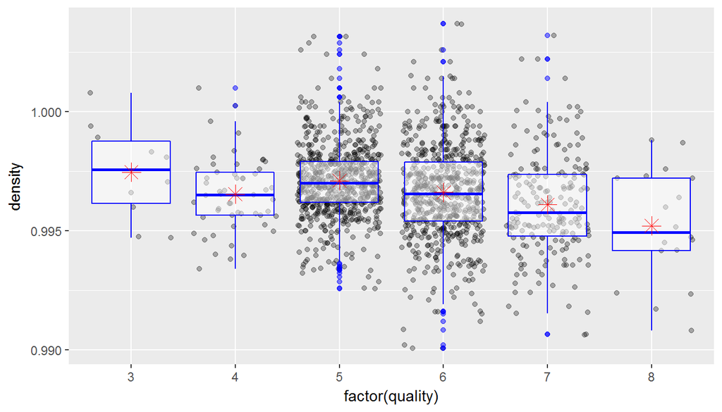

```
## red_wine$quality: 3
##    Min. 1st Qu.  Median    Mean 3rd Qu.    Max.
##  0.9947  0.9962  0.9976  0.9975  0.9988  1.0010
## --------------------------------------------------------
## red_wine$quality: 4
##    Min. 1st Qu.  Median    Mean 3rd Qu.    Max.
##  0.9934  0.9956  0.9965  0.9965  0.9974  1.0010
## --------------------------------------------------------
## red_wine$quality: 5
##    Min. 1st Qu.  Median    Mean 3rd Qu.    Max.
##  0.9926  0.9962  0.9970  0.9971  0.9979  1.0030
## --------------------------------------------------------
## red_wine$quality: 6
##    Min. 1st Qu.  Median    Mean 3rd Qu.    Max.
##  0.9901  0.9954  0.9966  0.9966  0.9979  1.0040
## --------------------------------------------------------
## red_wine$quality: 7
##    Min. 1st Qu.  Median    Mean 3rd Qu.    Max.
##  0.9906  0.9948  0.9958  0.9961  0.9974  1.0030
## --------------------------------------------------------
## red_wine$quality: 8
##    Min. 1st Qu.  Median    Mean 3rd Qu.    Max.
##  0.9908  0.9942  0.9949  0.9952  0.9972  0.9988
```

The plot of density versus quality is almost similar to the plot of alcohol versus quality. There is no significant change until the quality 5. From the quality 6 to 8, as the median of density for each quality decreases, the quality improves. It makes sense since the density of wine depends on the percent alcohol content.

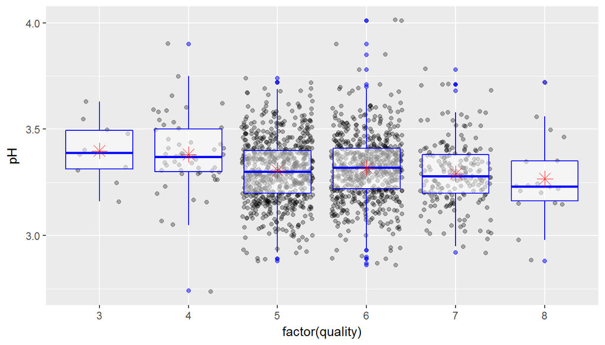

```
## red_wine$quality: 3
##    Min. 1st Qu.  Median    Mean 3rd Qu.    Max.
##   3.160   3.312   3.390   3.398   3.495   3.630
## --------------------------------------------------------
## red_wine$quality: 4
##    Min. 1st Qu.  Median    Mean 3rd Qu.    Max.
##   2.740   3.300   3.370   3.382   3.500   3.900
## --------------------------------------------------------
## red_wine$quality: 5
##    Min. 1st Qu.  Median    Mean 3rd Qu.    Max.
##   2.880   3.200   3.300   3.305   3.400   3.740
## --------------------------------------------------------
## red_wine$quality: 6
##    Min. 1st Qu.  Median    Mean 3rd Qu.    Max.
##   2.860   3.220   3.320   3.318   3.410   4.010
## --------------------------------------------------------
## red_wine$quality: 7
##    Min. 1st Qu.  Median    Mean 3rd Qu.    Max.
##   2.920   3.200   3.280   3.291   3.380   3.780
## --------------------------------------------------------
## red_wine$quality: 8
##    Min. 1st Qu.  Median    Mean 3rd Qu.    Max.
##   2.880   3.162   3.230   3.267   3.350   3.720
```

For the plot of pH versus quality, there is no significant difference between the medians of each quality. The values are near 3.3. The median of pH for each quality slightly decreases when improving the quality. It makes sense since the pH levels depends on the concentration of acids in the wine, better wines have higher amounts of fixed acidity and citric acid.